# LOG6308 - Systèmes de recommandations - Projet finale

**DERVAUX Gautier - 1971606**  
**MENGHETTI Marina -1971617**

## Project Description

Taken from 2018 [Kagle competition](https://https://www.kaggle.com/c/kkbox-music-recommendation-challenge), our project goal is to predict whether a user will listen again to song in the 30 days after they first listened to it.  
We have different datasets that come from [KKBox](https://www.kkbox.com/) an asian leader of music streaming. First, the ratings themselves, with the user_id and song_id as well with the context of their first listen. Moreover we have for every song: its duration, language, genre and others. We also have information on the users (called members): their gender, the time of subscription, their city etc. As an evaluation metric, the kaggle compeition focuses on the Area Under the Curve of the ROC curve. To be able to compare with the competition's leaderboard, we decided to use the same metrics to compare our different models. In order to be able to compute the ROC curve, we will predict a probability for the user to listen again the song during the month following the first listen. The threshold to predict the positive/negative class will be changed, in order to compute the different points of our ROC curve. Our report is organised likewise:

1. Data exploartion
2. Preparing the data
3. Baseline
4. The item-item approach
5. The Collaborative Deep learning with and without context
6. Conclusion and possible improvements  
   *Note that this notebook was run on the google colab platform*

```python
# Load the Drive helper and mount
from google.colab import drive
drive.mount('/content/drive')
```

```python
path = "drive/My\ Drive/Canada/Poly/Maitrise\ Pro/Automne\ 2019/LOG6308./Projet/"
drive_path = "drive/My\ Drive/"
figpath = path+'Figures/'
need_to_retrieve_data = True # need to retrieve data from Kaggle or not
```

```python
if need_to_retrieve_data:
  !mkdir -p ~/.kaggle
  !cp $drive_path/kaggle.json ~/.kaggle/ # You need a kaggle.json api token file and have accepted the competition rules to be able to download the data
  !chmod 600 ~/.kaggle/kaggle.json
  !ls ~/.kaggle

  # Install the Kaggle API
  !pip install -q kaggle
  !pip install -q kaggle-cli

  # Download the dataset
  !kaggle competitions download -c kkbox-music-recommendation-challenge
```

[output not shown]

```python
# unzip the files downloaded
!7za x  members.csv.7z
!7za x  songs.csv.7z
!7za x  song_extra_info.csv.7z
!7za x  train.csv.7z
!7za x  test.csv.7z
```

[output not shown]

[output cut: 99 more lines]

[output not shown]

```python
from collections import defaultdict, Counter
import matplotlib.pyplot as plt
import numpy as np
import seaborn as sns
import math
from scipy.sparse import csr_matrix, find
from sklearn.cluster import KMeans
from numpy.linalg import svd
from sklearn.decomposition import PCA
from sklearn.metrics import auc, roc_curve
from tensorflow.python.keras.utils import Sequence
from keras import backend as K
import tensorflow as tf
import pandas as pd
```

```python
figure_param = {'figsize':(10,9)}
title_size = 16
axis_label_size = 14
```

```python
dataPath = ''
train_full = pd.read_csv(dataPath+'train.csv')
test_full = pd.read_csv(dataPath+'test.csv')
song_extra_info = pd.read_csv(dataPath+'song_extra_info.csv')
members = pd.read_csv(dataPath+'members.csv')
# sample_submission = pd.read_csv(dataPath+'sample_submission.csv')
songs_full = pd.read_csv(dataPath+'songs.csv')
```

## Data exploring

### Vote and content information distribution

```python
train_full.shape, test_full.shape
```

```
((7377418, 6), (2556790, 6))
```

```python
trainWMembers = train_full.merge(members, how='left', on='msno')
trainnWSongs = train_full.merge(songs_full, how='left', on='song_id')
```

```python
members.head()
```

|  | msno | city | bd | gender | registered_via | registration_init_time | expiration_date |
| --- | --- | --- | --- | --- | --- | --- | --- |
| 0 | XQxgAYj3klVKjR3oxPPXYYFp4soD4TuBghkhMTD4oTw= | 1 | 0 | NaN | 7 | 20110820 | 20170920 |
| 1 | UizsfmJb9mV54qE9hCYyU07Va97c0lCRLEQX3ae+ztM= | 1 | 0 | NaN | 7 | 20150628 | 20170622 |
| 2 | D8nEhsIOBSoE6VthTaqDX8U6lqjJ7dLdr72mOyLya2A= | 1 | 0 | NaN | 4 | 20160411 | 20170712 |
| 3 | mCuD+tZ1hERA/o5GPqk38e041J8ZsBaLcu7nGoIIvhI= | 1 | 0 | NaN | 9 | 20150906 | 20150907 |
| 4 | q4HRBfVSssAFS9iRfxWrohxuk9kCYMKjHOEagUMV6rQ= | 1 | 0 | NaN | 4 | 20170126 | 20170613 |

```python
songs_full
```

|  | song_id | song_length | genre_ids | artist_name | composer | lyricist | language |
| --- | --- | --- | --- | --- | --- | --- | --- |
| 0 | CXoTN1eb7AI+DntdU1vbcwGRV4SCIDxZu+YD8JP8r4E= | 247640 | 465 | 張信哲 (Jeff Chang) | 董貞 | 何啟弘 | 3.0 |
| 1 | o0kFgae9QtnYgRkVPqLJwa05zIhRlUjfF7O1tDw0ZDU= | 197328 | 444 | BLACKPINK | TEDDY\| FUTURE BOUNCE\| Bekuh BOOM | TEDDY | 31.0 |
| 2 | DwVvVurfpuz+XPuFvucclVQEyPqcpUkHR0ne1RQzPs0= | 231781 | 465 | SUPER JUNIOR | NaN | NaN | 31.0 |
| 3 | dKMBWoZyScdxSkihKG+Vf47nc18N9q4m58+b4e7dSSE= | 273554 | 465 | S.H.E | 湯小康 | 徐世珍 | 3.0 |
| 4 | W3bqWd3T+VeHFzHAUfARgW9AvVRaF4N5Yzm4Mr6Eo/o= | 140329 | 726 | 貴族精選 | Traditional | Traditional | 52.0 |
| ... | ... | ... | ... | ... | ... | ... | ... |
| 2296315 | lg6rn7eV/ZNg0+P+x77kHUL7GDMfoL4eMtXxncseLNA= | 20192 | 958 | Catherine Collard | Robert Schumann (1810-1856) | NaN | -1.0 |
| 2296316 | nXi1lrSJe+gLoTTNky7If0mNPrIyCQCLwagwR6XopGU= | 273391 | 465 | 紀文惠 (Justine Chi) | NaN | NaN | 3.0 |
| 2296317 | 9KxSvIjbJyJzfEVWnkMbgR6dyn6d54ot0N5FKyKqii8= | 445172 | 1609 | Various Artists | NaN | NaN | 52.0 |
| 2296318 | UO8Y2MR2sjOn2q/Tp8/lzZTGKmLEvwZ20oWanG4XnYc= | 172669 | 465 | Peter Paul & Mary | NaN | NaN | 52.0 |
| 2296319 | V/9qPSUOGT0FeIGBhDIZRRz5Y5yyjdXC2Z/+bJExo5s= | 270466 | 829 | Kim Robertson | NaN | NaN | 52.0 |

2296320 rows × 7 columns

```python
trainnWSongs
```

[output not shown]

7377418 rows × 13 columns

```python
no_vote_songs = len(set(songs_full.song_id) - set(train_full.song_id))
print('Number of songs with information but no vote: {}, so {} % of all songs'.format(no_vote_songs, no_vote_songs/len(set(songs_full.song_id))*100))
```

```
Number of songs with information but no vote: 1936406, so 84.32648759754738 % of all songs
```

```python
vote_per_song = train_full.groupby(by='song_id')['target'].count()
```

[figure not shown]

```python
plt.figure(figsize=(20,9))
vote_per_song.hist(bins=50)
plt.xlabel('Number of votes')
plt.ylabel('Number of songs')
plt.title('Distribution of the number of votes among songs in the training data')
plt.show()
```

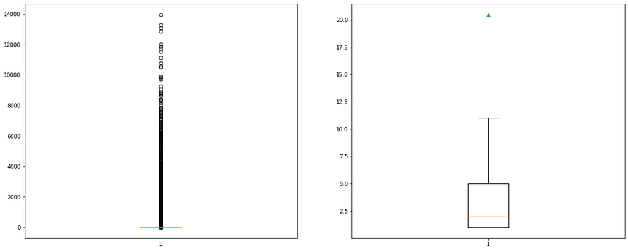

```python
plt.figure(figsize=(20,8))
plt.subplot(1,2,1)
plt.boxplot(vote_per_song)
plt.subplot(1,2,2)
plt.boxplot(vote_per_song, showfliers=False, showmeans=True)
plt.show()
```

```python
no_vote_users = len(set(members.msno) - set(train_full.msno))
print('Number of users with information but no vote: {}, so {} % of all users'.format(no_vote_users,no_vote_users/len(set(members.msno))*100))
```

```
Number of users with information but no vote: 3648, so 10.603726419207629 % of all users
```

```python
vote_per_user = train_full.groupby(by='msno')['target'].count()
```

```python
print('Number of users with 1 vote in the entire training data: {}, {} %'.format(len(vote_per_user[vote_per_user<=1]),len(vote_per_user[vote_per_user<=1])/len(vote_per_user)*100))
print('Number of users with less than 5 votes in the entire training data: {}, {} %'.format(len(vote_per_user[vote_per_user<=5]),len(vote_per_user[vote_per_user<=5])/len(vote_per_user)*100))
```

[output not shown]

[figure not shown]

```python
# Cumulative histogram

plt.figure(figsize=(20,9))
vote_per_user.hist(bins=50, cumulative=True, density=True, histtype='step')
ax = plt.gca()
plt.xlabel('Number of votes')
plt.ylabel('Number of users')
plt.title('Distribution of the number of votes among users in the training data')
plt.show()
```

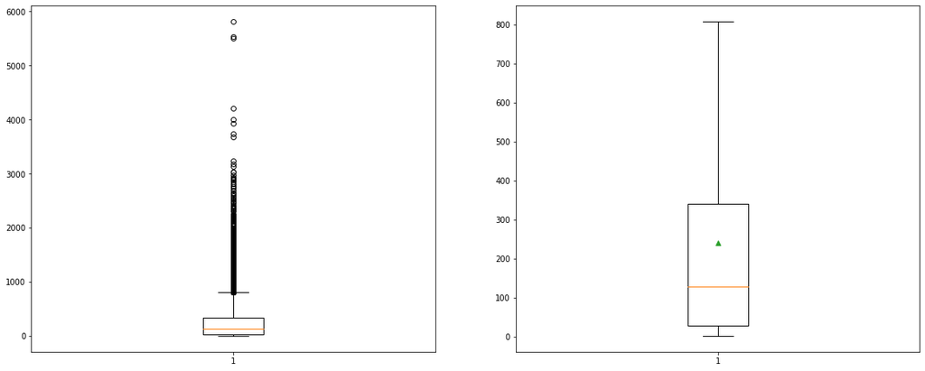

```python
plt.figure(figsize=(20,8))
plt.subplot(1,2,1)
plt.boxplot(vote_per_user)
plt.subplot(1,2,2)
plt.boxplot(vote_per_user, showfliers=False, showmeans=True)
plt.show()
```

The dataset is very big. We have informations on a lot of songs and users that don't necessarily have votes. More importantly, the ratings distribution is very unequal. The median number of votes per item is 2 whereas users have a median of more than a 100 votes. However, there is still many users with very few votes. This is a typical cold start problem. That's why we decided to use hybrid techniques that uses both the content information to handle those users and items, and the collaborative informations such as ratings.

### Content information's influence on the ratings

```python
def studyAttribute(train, attribute, plot=True, typeAttr=str):
  attributeValues = train[attribute].unique()
  ratios = [np.mean(train[ (train[attribute]==value) if type(value) is typeAttr or (type(value) is not float and not math.isnan(value)) else (train[attribute].isna())].target) for value in attributeValues ]
  if(plot):
    plt.figure(figsize=(10,5))
    plt.barh(range(len(attributeValues)), ratios)
    plt.yticks(range(len(attributeValues)),attributeValues)
  return attributeValues, ratios

def studyContinousAttribute(train, attribute, num_bucket=10, plot=True, log=True):
  min_val, max_val = min(train[attribute]), max(train[attribute])
  new_attr = attribute+"_discrete"
  attributeValues = train[attribute]
  if log:
    l = np.logspace(np.log10(min_val),np.log10(max_val),num=num_bucket)
    train[new_attr] = attributeValues.apply(lambda el: bisect(l, el))
  else:
    train[new_attr] = attributeValues.apply(lambda el: el//((max_val-min_val)/num_bucket))

  attributeValues, ratios = studyAttribute(train, new_attr, plot=False, typeAttr=np.float64)
  res_df = pd.DataFrame({"attributeValues":attributeValues,"ratios":ratios})
  res_df = res_df.sort_values(by='attributeValues')
  if(plot):
    plt.figure(figsize=(10,5))
    plt.scatter(res_df.attributeValues,res_df.ratios)
    ax = plt.gca()
    if log:
      ax.set_xticklabels(10**res_df.attributeValues)
    else:
      ax.set_xticklabels(np.linspace(min_val,max_val,num_bucket))

  return attributeValues, ratios
```

### Study users properties

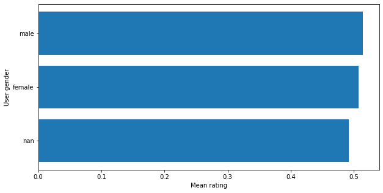

```python
genders, genderRations = studyAttribute(trainWMembers, 'gender', plot=True)
plt.xlabel('Mean rating')
plt.ylabel('User gender')
plt.show()
```

### Study context

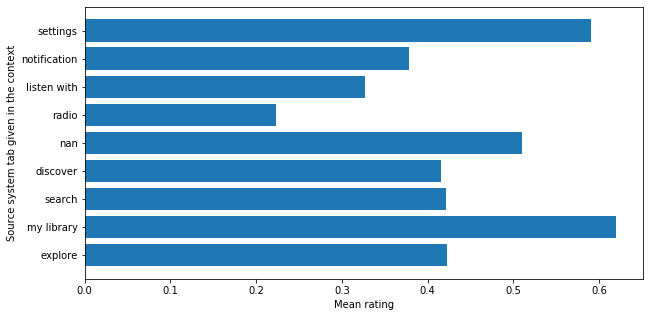

```python
sources, source_system_tab_ratio = studyAttribute(train_full, 'source_system_tab', plot=True)
plt.xlabel('Mean rating')
plt.ylabel('Source system tab given in the context')
plt.show()
```

### Study songs attributes

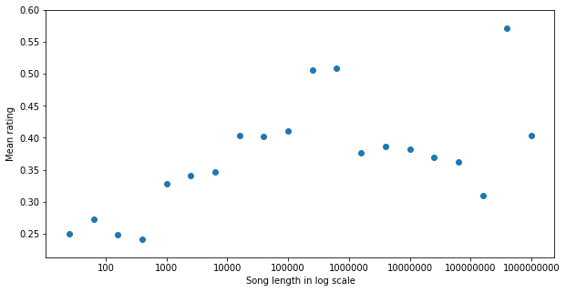

```python
songLength, songsRatios = studyContinousAttribute(trainnWSongs, 'song_length',num_bucket=20)
# songLength, songsRatios
plt.ylabel('Mean rating')
plt.xlabel('Song length in log scale')
plt.show()
```

As we expected, not all attributes seem to have a significant impact on the ratings. The gender doesn't really have an influence as we can see. The context, on the other hand, seem to have a great impact. It's quite reasonable that users are more likely to listen again to a song in their library, than one they listened on the radio. Indeed, if you listen a song on the radio, it's not always a song you like, and even if you like the song, you could not be able to find the song again in order to listen again to it.  
However this is a simple study. The gender coupled with other factors can bring more information.

## Preparing Data

As previously seen, the amount of data is larger than the ones from the labs and can lead to very long computation time. That's why we decided to train our models on a subset of the data: the first 10% of the ratings.  
To really measure our models' performances, we also extracted from the train a validation set. We'll train on the first set and evaluate the performance by predicting the ratings in the validation set, and comparing with the actual ratings.  
It's important to note that we take those two sets consecutively because the kaggle competition clearly states that the test data the teams had to predict is data that happened after the train in a timely fashion. The listens being ordered as well, taking consecutive sets and not random ones gives a better sense of the performance on the actual test dataset.

```python
train_size = int(train_full.shape[0]*0.1)
test_size =  int(train_full.shape[0]*0.01)
train = train_full[:train_size+test_size]
```

```python
def evaluateModel(predictions, ground_truth, plot=True, label=None, title=None):
    fpr,tpr,_= roc_curve(ground_truth,predictions)
    auc_score = auc(fpr,tpr)
    if(plot):
        plt.plot(fpr,tpr,label="AUC:"+str(np.round(auc_score,2))+" "+label)
        plt.xlabel('False Positive Rate',size=axis_label_size)
        plt.ylabel('True Positive Rate',size=axis_label_size)
        plt.title(title, size=title_size)
        plt.legend()
    return auc_score, fpr, tpr
```

### Ratings Matrix

```python
all_songs = set(train.song_id)
user_ids = set(train.msno)
all_songs_i = {key: index for index,key in enumerate(all_songs)}
user_ids_i = {key: index for index,key in enumerate(user_ids)}
```

```python
dense_col = []
dense_row = []
dense_data = []

for vote in train[['msno','song_id','target']].values:
    user_id = vote[0]
    song_id = vote[1]
    target = vote[2]*2-1
    dense_row.append(user_ids_i[user_id])
    dense_col.append(all_songs_i[song_id])
    dense_data.append(target) # 1 to 1 and 0 to -1
```

```python
max(list(all_songs_i.values()))
```

```
100815
```

```python
vote_matrix = csr_matrix((dense_data[:train_size],(dense_row[:train_size],dense_col[:train_size])),
                               shape=(max(dense_row[:train_size])+1,max(dense_col[:train_size])+1),
                               dtype=np.int8)
users_votes = defaultdict(list)
items_votes = defaultdict(list)
for user,song,vote in zip(dense_row[:train_size],dense_col[:train_size],dense_data[:train_size]):
  users_votes[user].append(vote)
  items_votes[song].append(vote)
```

```python
test_u, test_i, test_label = np.array(dense_row[train_size:train_size+test_size]), np.array(dense_col[train_size:train_size+test_size]), np.array(dense_data[train_size:train_size+test_size])
train_u, train_i, train_label = np.array(dense_row[:train_size]), np.array(dense_col[:train_size]), np.array(dense_data[:train_size]), context_vectors[:train_size]
```

```python
def perf_for_n_vote(test_u, test_i, test_label, num_vote_per_user, model, n_vote=0, lower_n_vote=0, context=None):
  test_index_n = list(filter(lambda x: x is not None,[i if num_vote_per_user[u]<=n_vote and num_vote_per_user[u]>=lower_n_vote else None for i,u in enumerate(test_u)]))

  test_u_n, test_i_n, test_label_n = test_u[test_index_n], test_i[test_index_n], test_label[test_index_n]
  if context is not None:
    context_n = context[test_index_n]
    test_label_n = test_label[test_index_n]
    predictions = model.predict(test_u_n, test_i_n, context_n, test_label_n)
  else:
    predictions = model.predict(test_u_n, test_i_n)
  auc,_,_ = evaluateModel(predictions, test_label_n, label="{}".format(model.name), title='Users between {} and {} votes in training data'.format(lower_n_vote,n_vote))
  return auc
```

### Context vectors

```python
context_vectors_string = train[['source_system_tab','source_screen_name','source_type']]
```

```python
context_vectors_one_hot = pd.concat([
                                    pd.get_dummies(context_vectors_string.source_system_tab,prefix=['source_system_tab'], dummy_na=True),
                                    pd.get_dummies(context_vectors_string.source_screen_name,prefix=['source_screen_name'], dummy_na=True),
                                    pd.get_dummies(context_vectors_string.source_type,prefix=['source_type'], dummy_na=True)
                                    ],axis=1)
```

```python
context_vectors_one_hot.head()
```

|  | ['source_system_tab']_discover | ['source_system_tab']_explore | ['source_system_tab']_listen with | ['source_system_tab']_my library | ['source_system_tab']_notification | ['source_system_tab']_radio | ['source_system_tab']_search | ['source_system_tab']_settings | ['source_system_tab']_nan | ['source_screen_name']_Album more | ['source_screen_name']_Artist more | ['source_screen_name']_Concert | ['source_screen_name']_Discover Chart | ['source_screen_name']_Discover Feature | ['source_screen_name']_Discover Genre | ['source_screen_name']_Discover New | ['source_screen_name']_Explore | ['source_screen_name']_Local playlist more | ['source_screen_name']_My library | ['source_screen_name']_My library_Search | ['source_screen_name']_Online playlist more | ['source_screen_name']_Others profile more | ['source_screen_name']_Radio | ['source_screen_name']_Search | ['source_screen_name']_Search Home | ['source_screen_name']_Search Trends | ['source_screen_name']_Self profile more | ['source_screen_name']_Unknown | ['source_screen_name']_nan | … |
| --- | --- | --- | --- | --- | --- | --- | --- | --- | --- | --- | --- | --- | --- | --- | --- | --- | --- | --- | --- | --- | --- | --- | --- | --- | --- | --- | --- | --- | --- | --- |
| 0 | 0 | 1 | 0 | 0 | 0 | 0 | 0 | 0 | 0 | 0 | 0 | 0 | 0 | 0 | 0 | 0 | 1 | 0 | 0 | 0 | 0 | 0 | 0 | 0 | 0 | 0 | 0 | 0 | 0 | … |
| 1 | 0 | 0 | 0 | 1 | 0 | 0 | 0 | 0 | 0 | 0 | 0 | 0 | 0 | 0 | 0 | 0 | 0 | 1 | 0 | 0 | 0 | 0 | 0 | 0 | 0 | 0 | 0 | 0 | 0 | … |
| 2 | 0 | 0 | 0 | 1 | 0 | 0 | 0 | 0 | 0 | 0 | 0 | 0 | 0 | 0 | 0 | 0 | 0 | 1 | 0 | 0 | 0 | 0 | 0 | 0 | 0 | 0 | 0 | 0 | 0 | … |
| 3 | 0 | 0 | 0 | 1 | 0 | 0 | 0 | 0 | 0 | 0 | 0 | 0 | 0 | 0 | 0 | 0 | 0 | 1 | 0 | 0 | 0 | 0 | 0 | 0 | 0 | 0 | 0 | 0 | 0 | … |
| 4 | 0 | 1 | 0 | 0 | 0 | 0 | 0 | 0 | 0 | 0 | 0 | 0 | 0 | 0 | 0 | 0 | 1 | 0 | 0 | 0 | 0 | 0 | 0 | 0 | 0 | 0 | 0 | 0 | 0 | … |

```python
context_vectors = context_vectors_one_hot.values
```

```python
train_context = context_vectors[:train_size]
test_context = context_vectors[train_size:train_size+test_size]
```

### Build item input vectors

```python
songs = songs_full[[song_id in all_songs_i.keys() for song_id in songs_full.song_id]]
songs.shape

song_vectors_one_hot = pd.concat([songs.song_id, songs.song_length,
                                pd.get_dummies(songs.genre_ids,prefix=['genre_ids'], dummy_na=True),
                                pd.get_dummies(songs.language,prefix=['language'], dummy_na=True)
                                ],axis=1)
```

```python
song_vectors_one_hot.song_id = song_vectors_one_hot.song_id.apply(lambda el: all_songs_i[el])
```

```python
unknow_songs = set(all_songs_i.values())-set(song_vectors_one_hot.song_id)
unknown_song_vector = np.zeros((len(unknow_songs),song_vectors_one_hot.shape[1]))
unknown_song_vector[:,0] = sorted(list(unknow_songs))
unknown_song_vector_df = pd.DataFrame(unknown_song_vector,columns= song_vectors_one_hot.columns)
```

```python
song_vectors_one_hot = pd.concat([song_vectors_one_hot,unknown_song_vector_df],axis=0).sort_values(by='song_id')
```

```python
song_vectors_one_hot.shape
```

```
(100816, 370)
```

```python
song_vectors_one_hot.head()
```

|  | song_id | song_length | ['genre_ids']_1000 | ['genre_ids']_1007 | ['genre_ids']_1011 | ['genre_ids']_1011\|691 | ['genre_ids']_1019 | ['genre_ids']_1026 | ['genre_ids']_1033 | ['genre_ids']_1040 | ['genre_ids']_1047 | ['genre_ids']_1054 | ['genre_ids']_1068 | ['genre_ids']_1082 | ['genre_ids']_109 | ['genre_ids']_1096 | ['genre_ids']_109\|1138 | ['genre_ids']_109\|118 | ['genre_ids']_109\|1259 | ['genre_ids']_109\|139 | ['genre_ids']_109\|465 | ['genre_ids']_1103 | ['genre_ids']_1138 | ['genre_ids']_1145 | ['genre_ids']_1152 | ['genre_ids']_1152\|2022 | ['genre_ids']_1152\|2122 | ['genre_ids']_1152\|2130\|2086\|374\|2122 | ['genre_ids']_1152\|242\|947 | … |
| --- | --- | --- | --- | --- | --- | --- | --- | --- | --- | --- | --- | --- | --- | --- | --- | --- | --- | --- | --- | --- | --- | --- | --- | --- | --- | --- | --- | --- | --- | --- |
| 76264 | 0.0 | 350014.0 | 0.0 | 0.0 | 0.0 | 0.0 | 0.0 | 0.0 | 0.0 | 0.0 | 0.0 | 0.0 | 0.0 | 0.0 | 0.0 | 0.0 | 0.0 | 0.0 | 0.0 | 0.0 | 0.0 | 0.0 | 0.0 | 0.0 | 0.0 | 0.0 | 0.0 | 0.0 | 0.0 | … |
| 11739 | 1.0 | 194716.0 | 0.0 | 0.0 | 0.0 | 0.0 | 0.0 | 0.0 | 0.0 | 0.0 | 0.0 | 0.0 | 0.0 | 0.0 | 0.0 | 0.0 | 0.0 | 0.0 | 0.0 | 0.0 | 0.0 | 0.0 | 0.0 | 0.0 | 0.0 | 0.0 | 0.0 | 0.0 | 0.0 | … |
| 52707 | 2.0 | 316116.0 | 0.0 | 0.0 | 0.0 | 0.0 | 0.0 | 0.0 | 0.0 | 0.0 | 0.0 | 0.0 | 0.0 | 0.0 | 0.0 | 0.0 | 0.0 | 0.0 | 0.0 | 0.0 | 0.0 | 0.0 | 0.0 | 0.0 | 0.0 | 0.0 | 0.0 | 0.0 | 0.0 | … |
| 1446477 | 3.0 | 189660.0 | 0.0 | 0.0 | 0.0 | 0.0 | 0.0 | 0.0 | 0.0 | 0.0 | 0.0 | 0.0 | 0.0 | 0.0 | 0.0 | 0.0 | 0.0 | 0.0 | 0.0 | 0.0 | 0.0 | 0.0 | 0.0 | 0.0 | 0.0 | 0.0 | 0.0 | 0.0 | 0.0 | … |
| 48610 | 4.0 | 364368.0 | 0.0 | 0.0 | 0.0 | 0.0 | 0.0 | 0.0 | 0.0 | 0.0 | 0.0 | 0.0 | 0.0 | 0.0 | 0.0 | 0.0 | 0.0 | 0.0 | 0.0 | 0.0 | 0.0 | 0.0 | 0.0 | 0.0 | 0.0 | 0.0 | 0.0 | 0.0 | 0.0 | … |

5 rows × 370 columns

```python
song_infomation_matrix = song_vectors_one_hot.drop('song_id',axis=1).values
song_infomation_matrix.shape
```

```
(100816, 369)
```

## Baseline

```python
class Baseline:
    def __init__(self, name, user_mean=True, item_mean=True):
      self.name = name
      self.user_mean = user_mean
      self.item_mean = item_mean
      return

    def predict(self, user_indeces, song_indeces):
      predictions = []
      for user_index,song_index in zip(user_indeces,song_indeces):
        user_mean = 0.5
        if self.user_mean and len(users_votes[user_index])>0:
          user_mean = np.mean(users_votes[user_index])

        item_mean = 0.5
        if self.item_mean and len(items_votes[song_index])>0:
          item_mean = np.mean(items_votes[song_index])

        predictions.append((user_mean+item_mean)/2)
      return predictions
```

```python
baseline = Baseline('Baseline')
baseline_predictions = baseline.predict(dense_row[train_size:train_size+test_size], dense_col[train_size:train_size+test_size])
auc_score,_,_ = evaluateModel(baseline_predictions, dense_data[train_size:train_size+test_size], plot=False)
print(auc_score)
```

```
0.6968483749408966
```

```python
num_vote_per_user = Counter(dense_row[:train_size])
num_vote_per_user_test = {u: num_vote_per_user[u] for u in test_u}
```

```python
baseline_row_col = Baseline('Baseline user and item mean')
baseline_col = Baseline('Baseline item mean', user_mean=False)
baseline_row = Baseline('Baseline user mean', item_mean=False)
```

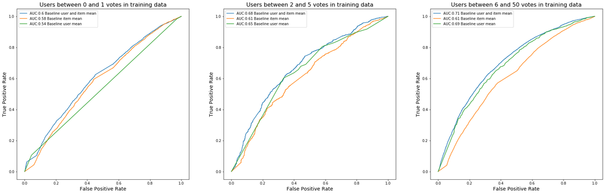

```python
plt.figure(figsize=(figure_param['figsize'][0]*3,figure_param['figsize'][1]))
plt.subplot(131)
perf_for_n_vote(test_u, test_i, test_label, num_vote_per_user, baseline_row_col, n_vote=1, lower_n_vote=0)
perf_for_n_vote(test_u, test_i, test_label, num_vote_per_user, baseline_col, n_vote=1, lower_n_vote=0)
perf_for_n_vote(test_u, test_i, test_label, num_vote_per_user, baseline_row, n_vote=1, lower_n_vote=0)
plt.subplot(132)
perf_for_n_vote(test_u, test_i, test_label, num_vote_per_user, baseline_row_col, n_vote=5, lower_n_vote=2)
perf_for_n_vote(test_u, test_i, test_label, num_vote_per_user, baseline_col, n_vote=5, lower_n_vote=2)
perf_for_n_vote(test_u, test_i, test_label, num_vote_per_user, baseline_row, n_vote=5, lower_n_vote=2)
plt.subplot(133)
perf_for_n_vote(test_u, test_i, test_label, num_vote_per_user, baseline_row_col, n_vote=50, lower_n_vote=6)
perf_for_n_vote(test_u, test_i, test_label, num_vote_per_user, baseline_col, n_vote=50, lower_n_vote=6)
perf_for_n_vote(test_u, test_i, test_label, num_vote_per_user, baseline_row, n_vote=50, lower_n_vote=6)
# figname = 'baseline_comparaison'
# plt.savefig(figname)
# !mv $figname'.png' $figpath
plt.show()
```

To better see the performance of the models, we splitted the curves according the the amount of votes of validation users in the training dataset .  
As we can observe the model that does the average of both the user's rating and the item's ratings outperforms the models that take only one of them into account. It follows the same trend as what we saw during the labs. It's interesting to observe that the AUC increases with the number.  
The best model will acts as our baseline for the rest of this project.

## Item Item

```python
from sklearn.metrics.pairwise import cosine_similarity
from sklearn.metrics import mean_squared_error

class ItemItem:

    def __init__(self, K, name, metric = cosine_similarity):
        self.K = K #Number of neighbour
        self.simi_metric = cosine_similarity
        self.songNeigboursCos = {} #Keep neighbours cos similarity to speed predictions after train
        self.name = name

    def predict_one(self, user_index, song_index):

      if len(items_votes[song_index])==0:
        return 0

      if song_index not in self.songNeigboursCos:
          song_vector = vote_matrix[:,song_index]
          song_cos_simi = self.simi_metric(np.transpose(vote_matrix),np.transpose(song_vector))

          song_neigbours  = song_cos_simi.reshape((len(song_cos_simi),)).argsort()[-self.K-1:-1][::-1]
          song_neigbours_cos = song_cos_simi[song_neigbours].reshape((self.K,))
          self.songNeigboursCos[song_index] = (song_neigbours_cos,song_neigbours)
      else:
          (song_neigbours_cos,song_neigbours) = self.songNeigboursCos[song_index]

      _, non_zero_neighbour, non_zero_neighbour_targets = find(vote_matrix[user_index,song_neigbours])

      if len(non_zero_neighbour_targets)==0 or sum(song_neigbours_cos[non_zero_neighbour])==0:
        return 0.5

      non_zero_neighbour_cos = song_neigbours_cos[non_zero_neighbour]/sum(song_neigbours_cos[non_zero_neighbour])
      pred = (np.dot(non_zero_neighbour_cos,non_zero_neighbour_targets)+1)/2
      return pred

    def predict(self, batch_user_index , batch_song_index, print_progress=False):
        predictions_itemitem = []
        n = 0

        for u,i in zip(batch_user_index,batch_song_index):
          prediction = self.predict_one(u,i)
          predictions_itemitem.append(prediction)
          if print_progress:
            n+=1
            print(n/len(batch_user_index)*100)

        return predictions_itemitem
```

```python
item = ItemItem(1000)
```

```python
predictions_itemitem = item.predict(test_u,test_i)
```

```
0.6525358381567754
```

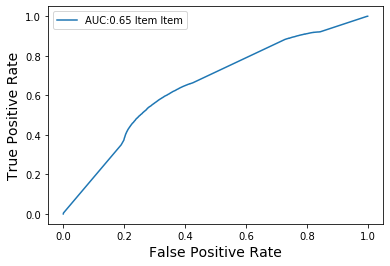

```python
auc_score,_,_ = evaluateModel(predictions_itemitem, test_label, plot=True, label='Item Item')
print(auc_score)
```

```python
item.name = 'ItemItem 1000 neighbours'
```

```python
plt.figure(figsize=(figure_param['figsize'][0]*3,figure_param['figsize'][1]*2))
plt.subplot(231)
perf_for_n_vote(test_u, test_i, test_label, num_vote_per_user, item, n_vote=1, lower_n_vote=0)
perf_for_n_vote(test_u, test_i, test_label, num_vote_per_user, baseline_row_col, n_vote=1, lower_n_vote=0)

plt.subplot(232)
perf_for_n_vote(test_u, test_i, test_label, num_vote_per_user, item, n_vote=5, lower_n_vote=2)
perf_for_n_vote(test_u, test_i, test_label, num_vote_per_user, baseline_row_col, n_vote=5, lower_n_vote=2)

plt.subplot(233)
perf_for_n_vote(test_u, test_i, test_label, num_vote_per_user, item, n_vote=50, lower_n_vote=6)
perf_for_n_vote(test_u, test_i, test_label, num_vote_per_user, baseline_row_col, n_vote=50, lower_n_vote=6)

plt.subplot(234)
perf_for_n_vote(test_u, test_i, test_label, num_vote_per_user, item, n_vote=100, lower_n_vote=51)
perf_for_n_vote(test_u, test_i, test_label, num_vote_per_user, baseline_row_col, n_vote=100, lower_n_vote=51)

plt.subplot(235)
perf_for_n_vote(test_u, test_i, test_label, num_vote_per_user, item, n_vote=150, lower_n_vote=101)
perf_for_n_vote(test_u, test_i, test_label, num_vote_per_user, baseline_row_col, n_vote=150, lower_n_vote=101)

plt.subplot(236)
perf_for_n_vote(test_u, test_i, test_label, num_vote_per_user, item, n_vote=200, lower_n_vote=151)
perf_for_n_vote(test_u, test_i, test_label, num_vote_per_user, baseline_row_col, n_vote=200, lower_n_vote=151)


# figname = 'baseline_itemitem_comparaison'
# plt.savefig(figname)
# !mv $figname'.png' $figpath

plt.show()
```

[figure not shown]

As the figures above show, the item item approach does not improve the baseline. Even with 1000 neighbours which gave the best results, the model struggles a lot with cold start user wich is not surprising. However even with more ratings, the approach still underperforms the baseline.  
To solve this cold start issue, one needs to add data about the user or the item, or both.

## Collaborative Deep Learning

Inspired by https://github.com/ChenBoSyun/implement-Collaborative-Deep-Learning-for-Recommender-Systems/blob/master/CDL_tf.ipynb and https://www.pyimagesearch.com/2018/06/04/keras-multiple-outputs-and-multiple-losses/ and https://github.com/zoujun123/Keras-CDL/blob/master/CDL.py

As our data exploring pointed out, the content information can add very precious information on the target. To use that, we decided to implement the Collaborative Deep Learning approach Gautier presented in class. The model presented only takes into account item content information, but in this problem, the context seems also important. Therefore we tried two architectures, one similar to the one by the authors and a modified version with the context. The schemas are from the presentation we did.

##### The Vanilla version from the paper

[figure not shown]

##### The version with a context added

[figure not shown]

```python
import numpy as np
import logging
from keras.layers import Input, Embedding, Dot, Flatten, Dense, Dropout, Lambda, Add, Activation
from keras.layers.noise import GaussianNoise
from keras.initializers import RandomUniform, RandomNormal
from keras.models import Model
from keras.regularizers import l2
from keras import optimizers
from keras import backend as K
from keras.engine.topology import Layer
```

```python
train_mat = (train_u,train_i,train_label,train_context)
test_mat = (test_u,test_i,test_label,test_context)
```

```python
class BatchGenerator(Sequence):
    def __init__(self, users, items, ratings, context, batch_size, item_mat):
        self.users, self.context, self.items, self.ratings = users, context, items, ratings
        self.batch_size = batch_size
        self.item_mat = item_mat

    def __len__(self):
        return len(self.users)//self.batch_size+1

    def __getitem__(self, idx):

        user = self.users[idx*self.batch_size:(idx+1)*self.batch_size]
        items = self.items[idx*self.batch_size:(idx+1)*self.batch_size]
        item_feat = np.array([self.item_mat[items[x]] for x in range(items.shape[0])])

        ratings = self.ratings[idx*self.batch_size:(idx+1)*self.batch_size]

        if self.context is not None:
          context = self.context[idx*self.batch_size:(idx+1)*self.batch_size]
          return([user.reshape((len(user),-1)), context, items.reshape((len(user),-1)), item_feat],[ratings.reshape((len(user),-1)), item_feat])
        else:
          return([user.reshape((len(user),-1)), items.reshape((len(user),-1)), item_feat],[ratings.reshape((len(user),-1)), item_feat])
```

```python
class CollaborativeDeepLearning:
  def __init__(self, item_mat, hidden_layers, name='CDL', context=True):
    '''
    hidden_layers = a list of three integer indicating the embedding dimension of autoencoder
    item_mat = item feature matrix with shape (# of item, # of item features)
    '''
    assert(len(hidden_layers)==3)
    self.item_mat = item_mat
    self.hidden_layers = hidden_layers
    self.item_dim = hidden_layers[0]
    self.embedding_dim = hidden_layers[-1]
    self.name = name
    self.history = None
    self.context = context

  def pretrain(self, lamda_w=0.1, encoder_noise=0.1, dropout_rate=0.1, activation='sigmoid', batch_size=64, epochs=10):
    '''
    layer-wise pretraining on item features (item_mat)
    '''
    self.trained_encoders = []
    self.trained_decoders = []
    X_train = self.item_mat
    layer_index = 0

    for input_dim, hidden_dim in zip(self.hidden_layers[:-1], self.hidden_layers[1:]):
      print('Pretraining the layer: Input dim {} -> Output dim {}'.format(input_dim, hidden_dim))
      pretrain_input = tf.keras.layers.Input(shape=(input_dim,))
      encoded = tf.keras.layers.GaussianNoise(stddev=encoder_noise)(pretrain_input)
      encoded = tf.keras.layers.Dropout(dropout_rate)(encoded)
      encoder = tf.keras.layers.Dense(hidden_dim, activation=activation, kernel_regularizer=l2(lamda_w), bias_regularizer=l2(lamda_w))(encoded)
      decoder = tf.keras.layers.Dense(input_dim, activation=activation, kernel_regularizer=l2(lamda_w), bias_regularizer=l2(lamda_w))(encoder)
      # autoencoder
      ae = tf.keras.models.Model(inputs=pretrain_input, outputs=decoder)
      # encoder
      ae_encoder = tf.keras.models.Model(inputs=pretrain_input, outputs=encoder)
      # decoder
      encoded_input = tf.keras.layers.Input(shape=(hidden_dim,))
      decoder_layer = ae.layers[-1] # the last layer
      ae_decoder = tf.keras.models.Model(encoded_input, decoder_layer(encoded_input))

      ae.compile(loss='mse', optimizer='adam')
      ae.fit(X_train, X_train, batch_size=batch_size, epochs=epochs, verbose=2)

      self.trained_encoders.append(ae_encoder)
      self.trained_decoders.append(ae_decoder)
      X_train = ae_encoder.predict(X_train)

  def buildFullModel(self, train_mat, test_mat, lamda_u=0.1, lamda_v=0.1, lamda_n=0.1, lr=0.001):
    '''
    Fine-tuning with rating prediction
    '''
    train_u, train_i, train_label, train_context = train_mat
    test_u, test_i, test_label, test_context = test_mat
    num_user = int( max(train_u.max(),test_u.max()) + 1 )
    num_item = int( max(train_i.max(),test_i.max()) + 1 )
    print("num user {} num item {}".format(num_user,num_item))

    # item autoencoder
    itemfeat_InputLayer = tf.keras.layers.Input(shape=(self.item_dim,), name='item_feat_input')
    encoded = self.trained_encoders[0](itemfeat_InputLayer)
    encoded = self.trained_encoders[1](encoded)
    decoded = self.trained_decoders[1](encoded)
    decoded = self.trained_decoders[0](decoded)

    # user embedding
    user_InputLayer = tf.keras.layers.Input(shape=(1,), dtype='int32', name='user_input')
    user_EmbeddingLayer = tf.keras.layers.Embedding(input_dim=num_user, output_dim=self.embedding_dim, input_length=1, name='user_embedding', embeddings_regularizer=l2(lamda_u),
                                    embeddings_initializer=RandomNormal(mean=0, stddev=1))(user_InputLayer)
    user_EmbeddingLayer = tf.keras.layers.Flatten(name='user_flatten')(user_EmbeddingLayer)

    # item embedding
    item_InputLayer = tf.keras.layers.Input(shape=(1,), dtype='int32', name='item_input')
    item_OffsetVector = tf.keras.layers.Embedding(input_dim=num_item, output_dim=self.embedding_dim, input_length=1, name='item_offset_vector', embeddings_regularizer=l2(lamda_v),
                                  embeddings_initializer=RandomNormal(mean=0, stddev=1))(item_InputLayer)
    item_OffsetVector = tf.keras.layers.Flatten(name='item_flatten')(item_OffsetVector)
    item_EmbeddingLayer = tf.keras.layers.Add()([encoded, item_OffsetVector])

    if self.context:
      # context embedding
      context_InputLayer = tf.keras.layers.Input(shape=(train_context.shape[1],), name='context_input')
      context_dim_reductions = tf.keras.layers.Dense(self.embedding_dim, activation=K.relu)(context_InputLayer)

      context_user = tf.keras.layers.Add()([context_dim_reductions, user_EmbeddingLayer])

      # rating prediction
      dotLayer = tf.keras.layers.Dot(axes = -1)([context_user, item_EmbeddingLayer])
      dotLayer = tf.keras.layers.Activation('tanh',name='dot_layer')(dotLayer)

      self.cdl_model = tf.keras.models.Model(inputs=[user_InputLayer, context_InputLayer, item_InputLayer, itemfeat_InputLayer], outputs=[dotLayer, decoded])
    else:
      # rating prediction
      dotLayer = tf.keras.layers.Dot(axes = -1)([user_EmbeddingLayer, item_EmbeddingLayer])
      dotLayer = tf.keras.layers.Activation('tanh',name='dot_layer')(dotLayer)

      self.cdl_model = tf.keras.models.Model(inputs=[user_InputLayer, item_InputLayer, itemfeat_InputLayer], outputs=[dotLayer, decoded])

    self.cdl_model.compile(optimizer='adam', loss=['mse', 'mse'], loss_weights=[1, lamda_n])

  def train(self, train_mat, test_mat, batch_size=64, epochs=10):

    train_u, train_i, train_label, train_context = train_mat
    test_u, test_i, test_label, test_context = test_mat

    if not self.context:
      train_context, test_context = None, None

    train_generator = BatchGenerator(train_u, train_i, train_label, train_context, batch_size, self.item_mat)
    test_generator = BatchGenerator(test_u, test_i, test_label, test_context, batch_size, self.item_mat)

    model_history = self.cdl_model.fit_generator(generator=train_generator,
                                                validation_data=test_generator,
                                                use_multiprocessing=True,
                                                workers=4,
                                                epochs=epochs)
    if self.history is None:
      self.history = model_history
    else:
      max_previous_epoch = max(self.history.epoch)
      self.history.epoch += list(range(max_previous_epoch+1,max_previous_epoch+epochs+1))
      for key in self.history.history:
        self.history.history[key] += model_history.history[key]

    return model_history

  def getRMSE(self, test_mat, print_auc=True, label="CDL test"):

    test_u, test_i, test_label, test_context = test_mat
    predictions = self.predict(test_u, test_i, test_context, test_label)
    if(print_auc):
        evaluateModel((np.array(predictions)+1)/2,(np.array(test_label)+1)/2, plot=True, label=label)
    return np.sqrt(np.mean(np.square(np.array(test_label) - np.array(predictions))))

  def predict(self, u, i, context, label):
    batch_size = 256

    if not self.context:
      context = None

    generator = BatchGenerator(u, i, label, context, batch_size, self.item_mat)
    predictions = []

    for i in range(generator.__len__()):
      if self.context:
        [u, context, item, item_feat], [label, item_feat] = generator.__getitem__(i)
        [pred_out, decoded_out] = self.cdl_model.predict([u, context, item, item_feat])
      else:
        [u, item, item_feat], [label, item_feat] = generator.__getitem__(i)
        [pred_out, decoded_out] = self.cdl_model.predict([u, item, item_feat])
      predictions += list(pred_out.flatten())

    return predictions

  def printAuc(self, test_mat, plot_label="CDL"):
    test_u, test_i, test_label, test_context = test_mat
    pred_test = self.predict(test_u, test_i, test_context, test_label)
    auc_score_test, _, _ = evaluateModel(pred_test, test_label, label=plot_label)
    # plt.show()
    return auc_score_test
```

### CDL Without Context

```python
num_item_feat = song_infomation_matrix.shape[1]
cdl = CollaborativeDeepLearning(song_infomation_matrix, [num_item_feat, 32, 16], name='CDL', context=False)
cdl.pretrain(lamda_w=0.001, encoder_noise=0.3, epochs=10)
cdl.buildFullModel(train_mat, test_mat, lamda_u=0.1, lamda_v=0.1, lamda_n=0.1, lr=0.001)
```

```
Pretraining the layer: Input dim 369 -> Output dim 32
Train on 100816 samples
100816/100816 - 12s - loss: 193200751.4744
100816/100816 - 6s - loss: 193200726.1933
100816/100816 - 6s - loss: 193200726.9652
100816/100816 - 6s - loss: 193200726.8129
100816/100816 - 6s - loss: 193200726.9703
100816/100816 - 6s - loss: 193200726.5082
100816/100816 - 6s - loss: 193200727.0236
100816/100816 - 6s - loss: 193200726.7900
100816/100816 - 6s - loss: 193200727.2953
100816/100816 - 6s - loss: 193200726.9399
Pretraining the layer: Input dim 32 -> Output dim 16
Train on 100816 samples
100816/100816 - 11s - loss: 0.0420
100816/100816 - 5s - loss: 0.0226
100816/100816 - 5s - loss: 0.0226
100816/100816 - 5s - loss: 0.0226
100816/100816 - 5s - loss: 0.0226
100816/100816 - 5s - loss: 0.0226
100816/100816 - 5s - loss: 0.0226
100816/100816 - 5s - loss: 0.0226
100816/100816 - 5s - loss: 0.0226
100816/100816 - 5s - loss: 0.0226
num user 16262 num item 100816
```

```
Testing RMSE = 0.9959842167301829
```

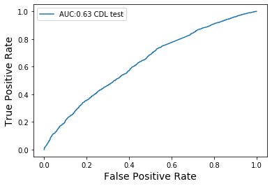

```python
model_history = cdl.train(train_mat, test_mat, epochs=20, batch_size=128*16*2)
testing_rmse = cdl.getRMSE(test_mat)
print('Testing RMSE = {}'.format(testing_rmse))
```

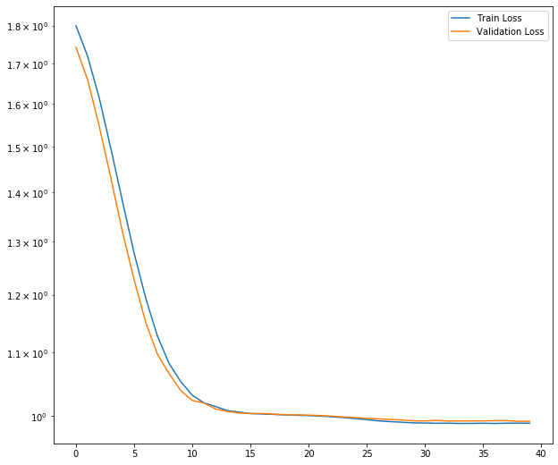

```python
# model_history.history
plt.figure(**figure_param)
plt.plot(cdl.history.epoch,cdl.history.history["dot_layer_loss"],label='Train Loss')
plt.plot(cdl.history.epoch,cdl.history.history["val_dot_layer_loss"],label='Validation Loss')
plt.semilogy()
plt.legend()
plt.show()
```

### CDL With Context

```python
num_item_feat = song_infomation_matrix.shape[1]
context_cdl = CollaborativeDeepLearning(song_infomation_matrix, [num_item_feat, 32, 16], name='CDL with context')
context_cdl.pretrain(lamda_w=0.001, encoder_noise=0.3, epochs=10)
context_cdl.buildFullModel(train_mat, test_mat, lamda_u=0.1, lamda_v=0.1, lamda_n=0.1, lr=0.001)
```

```
Pretraining the layer: Input dim 369 -> Output dim 32
Train on 100816 samples
100816/100816 - 12s - loss: 193200761.8829
100816/100816 - 6s - loss: 193200726.4904
100816/100816 - 6s - loss: 193200726.7240
100816/100816 - 6s - loss: 193200726.8230
100816/100816 - 6s - loss: 193200727.0770
100816/100816 - 6s - loss: 193200726.8941
100816/100816 - 6s - loss: 193200726.9348
100816/100816 - 6s - loss: 193200726.7532
100816/100816 - 6s - loss: 193200727.1608
100816/100816 - 6s - loss: 193200726.9195
Pretraining the layer: Input dim 32 -> Output dim 16
Train on 100816 samples
100816/100816 - 10s - loss: 0.0417
100816/100816 - 5s - loss: 0.0228
100816/100816 - 5s - loss: 0.0228
100816/100816 - 5s - loss: 0.0228
100816/100816 - 5s - loss: 0.0228
100816/100816 - 5s - loss: 0.0228
100816/100816 - 5s - loss: 0.0228
100816/100816 - 5s - loss: 0.0228
100816/100816 - 5s - loss: 0.0228
100816/100816 - 5s - loss: 0.0228
num user 16262 num item 100816
```

```
Testing RMSE = 0.9043647413672342
```

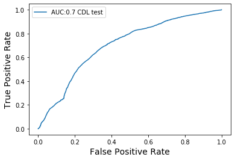

```python
model_history = context_cdl.train(train_mat, test_mat, epochs=20, batch_size=128*16)
testing_rmse = context_cdl.getRMSE(test_mat)
print('Testing RMSE = {}'.format(testing_rmse))
```

```
0.7019557306559266
```

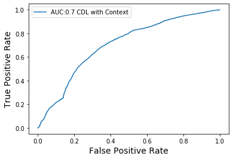

```python
pred_test = context_cdl.predict(test_u, test_i, test_context, test_label)
auc_score_test, _, _ = evaluateModel( (np.array(pred_test)+1)/2,(np.array(test_label)+1)/2, label='CDL with Context')
auc_score_test
```

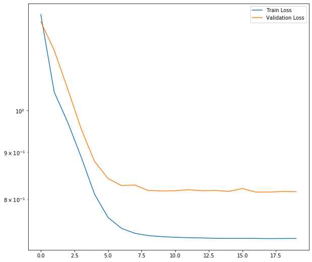

```python
# model_history.history
plt.figure(**figure_param)
plt.plot(context_cdl.history.epoch,context_cdl.history.history["dot_layer_loss"],label='Train Loss')
plt.plot(context_cdl.history.epoch,context_cdl.history.history["val_dot_layer_loss"],label='Validation Loss')
plt.semilogy()
plt.legend()
plt.show()
```

### Results

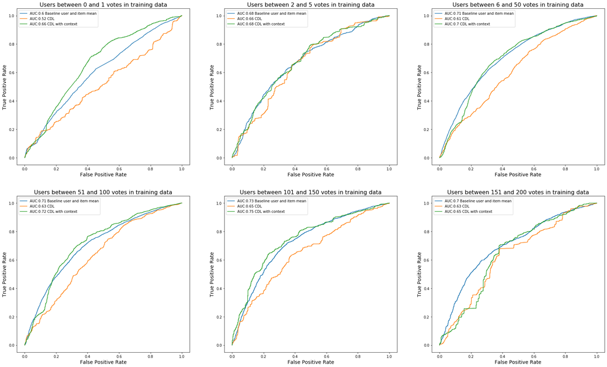

```python
plt.figure(figsize=(figure_param['figsize'][0]*3,figure_param['figsize'][1]*2))
plt.subplot(231)
perf_for_n_vote(test_u, test_i, test_label, num_vote_per_user, baseline_row_col, n_vote=1, lower_n_vote=0)
perf_for_n_vote(test_u, test_i, test_label, num_vote_per_user, cdl, n_vote=1, context=test_context, lower_n_vote=0)
perf_for_n_vote(test_u, test_i, test_label, num_vote_per_user, context_cdl, context=test_context, n_vote=1, lower_n_vote=0)

plt.subplot(232)
perf_for_n_vote(test_u, test_i, test_label, num_vote_per_user, baseline_row_col, n_vote=5, lower_n_vote=2)
perf_for_n_vote(test_u, test_i, test_label, num_vote_per_user, cdl, context=test_context, n_vote=5, lower_n_vote=2)
perf_for_n_vote(test_u, test_i, test_label, num_vote_per_user, context_cdl, context=test_context, n_vote=5, lower_n_vote=2)

plt.subplot(233)
perf_for_n_vote(test_u, test_i, test_label, num_vote_per_user, baseline_row_col, n_vote=50, lower_n_vote=6)
perf_for_n_vote(test_u, test_i, test_label, num_vote_per_user, cdl, context=test_context, n_vote=50, lower_n_vote=6)
perf_for_n_vote(test_u, test_i, test_label, num_vote_per_user, context_cdl, context=test_context, n_vote=50, lower_n_vote=6)

plt.subplot(234)
perf_for_n_vote(test_u, test_i, test_label, num_vote_per_user, baseline_row_col, n_vote=100, lower_n_vote=51)
perf_for_n_vote(test_u, test_i, test_label, num_vote_per_user, cdl, context=test_context, n_vote=100, lower_n_vote=51)
perf_for_n_vote(test_u, test_i, test_label, num_vote_per_user, context_cdl, context=test_context, n_vote=100, lower_n_vote=51)

plt.subplot(235)
perf_for_n_vote(test_u, test_i, test_label, num_vote_per_user, baseline_row_col, n_vote=150, lower_n_vote=101)
perf_for_n_vote(test_u, test_i, test_label, num_vote_per_user, cdl, context=test_context, n_vote=150, lower_n_vote=101)
perf_for_n_vote(test_u, test_i, test_label, num_vote_per_user, context_cdl, context=test_context, n_vote=150, lower_n_vote=101)

plt.subplot(236)
perf_for_n_vote(test_u, test_i, test_label, num_vote_per_user, baseline_row_col, n_vote=200, lower_n_vote=151)
perf_for_n_vote(test_u, test_i, test_label, num_vote_per_user, cdl, context=test_context, n_vote=200, lower_n_vote=151)
perf_for_n_vote(test_u, test_i, test_label, num_vote_per_user, context_cdl, context=test_context, n_vote=200, lower_n_vote=151)


# figname = 'baseline_cdl_comparaison'
# plt.savefig(figname)
# !mv $figname'.png' $figpath

plt.show()
```

One can observe that the CDL method without any context does not improve the baseline. But with the context information, we actually improve the baseline! Especially, when focusing with cold start user, the CDL with context achieves a 0.66 compared to the 0.6 auc of the baseline. Our first hint on the context data is confirmed.

## Conclusion and Possible Improvements

In conclusion, this competition was really interesting and quite complex. The sparsity of the vote_matrix due to its size is a tough problem to solve. Collaborative data alone is not powerful enough to make good predictions, but not all content information have the same impact on the performance.  
There is still a lot of room for improvement on our system. We could first improve the representation of the song. For exemple, some songs can have two different genre but here we considered it as a different one. We could include more information on the songs like the popularity of the artists for instance or the name of the songs.  
We could also explore more the parameters of the CDL like the reconstruction objectif weigh or the noise parameters.  
We also thought about different architectures that take the user informations as well as the context. We could introduce a second reconstruction objectif on them as well.

##### Future work: addition of user information in the architecture

[figure not shown]

##### Future work: addition of a second reconstruction objective for the representation of "a user in a specific context"

[figure not shown]

What was especially interesting in this project was the information about the context. Usually we have information about item and users, and the ratings. But in this project we have informations about ratings themselves. We didn't see in the course how to use this type of information, and using it with an architecture that makes sense was a challenge.